# MIDI-MT - Модуль взаимодействия с «Джойстиками/Геймпадами»

MIDI-MT Документация на Русском языке

## Управление с помощью «Джойстика» и «Геймпада»

- Настройки модуля взаимодействия с «Джойстиками» и «Геймпадами»
  - Режим управления
  - Ограничения
- Настройки привязок органов управления
- Конфигурационный файл

Позволяет использовать стандартные «**Джойстики**» и «**Геймпады**» в двух режимах, как клавиатуру ввода, или как пульт дистанционного управления. Модуль транслирует команды с геймпада или джойстика в MIDI протокол. В режиме «**устройство ввода**», управление направлениями используются как слайдеры, а кнопки используются по прямому назначению.

### Настройки модуля взаимодействия с «Джойстиками» и «Геймпадами»

- Список «**Доступные устройства**» показывают подключенные устройства на текущий момент.
- Выбор «**Шаг изменений**» задаёт шкалу регулировки, доступные значения, от `1` до `42`. Максимальное значение шкалы `127`.
- Выбор «**Период опроса устройств**» задает промежуток времени в миллисекундах между опросом подключенных устройств. Значение по умолчанию 50 миллисекунд.
- Переключатель «**Режим ввода**»/«**Режим управления**» устанавливает исполняемые функции устройств. В режим ввода, устройства работают как внешняя MIDI клавиатура, в режиме управления - как пульт дистанционного управления группами «**Аудио Микшер**», «**Умный Дом**» и «**Упрааление Светом**».
- Поле «**Сцена**» позволяет указать номер MIDI сцены, в случае конфликта с другими подключёнными MIDI устройствами. Значение по умолчанию `101`.
- Опция «**Использовать направления как кнопки**» работает в режиме устройства ввода и позволяет использовать каждое управление по направлениям (плоскостям), как 4 независимые кнопки.
- Опция «**Горизонтальные направления в режиме JOG**» заставляет использовать горизонтальное направление в `бесконечном` режиме. Удобно использовать в «Adobe Prmiere Pro» для перемещения по тайм-лайну.
- Выбор «**Настройки режима управления**» позволяет ограничить управляемые группы одной или несколько, из списка групп «**Аудио Микшер**», «**Умный Дом**» и «**Упрааление Светом**».

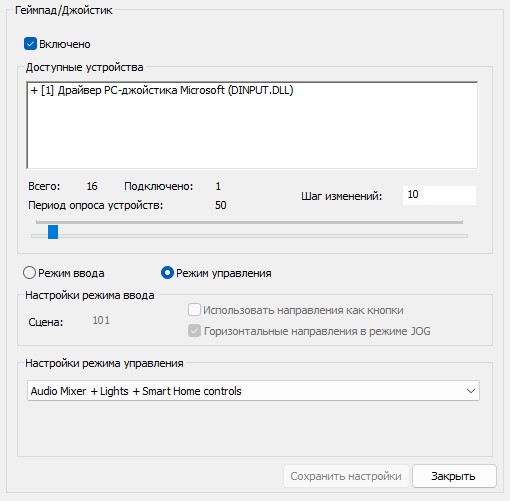

С помощью Геймпада или Джойстика вы можете управлять всеми регуляторами типа ‘**Slider**’, ‘**Fader**’ или ‘**Jog**’ настроенными в конфигурации `MIDI-MT`. В режиме управления, регулировка возможна в группах «**Аудио Микшер**», «**Умный Дом**» и «**Упрааление Светом**», все подключенные устройства дублируют функции друг друга.

###### Режим управления:

1. Логика работы в режиме управления:

Горизонтальными направлениями вы выбираете контрол, а вертикальными регулируете уровень. Смена регулируемых групп производиться кнопками `1` и `2` на устройстве. Кнопка `3` отвечает за включение/отключение выбранного контрола. Кнопка `4` устанавливает средний уровень для выбранного контрола, или возвращает его предыдущее значение. Все кнопки, кроме `1` и `2`, имеют триггерное поведение. Кнопки `1` и `2` работают в режиме «листания». В режиме управления все подключенные устройства дублируют друг друга.

2. Комбинации клавиш в режиме управления:
- кнопки `1`,`2`: листание групп, в соответствии с выбором «Настройки режима управления».
- `горизонтальное направление`: листание контролов в группе (вправо/влево).
- `вертикальное направление`: увеличение или уменьшение значений (вверх/вниз), в соответствии с ввбором «Шаг изменений»
- кнопка `3`: временная установка значения на `0`, без внесения изменений в базу.
- кнопка `4`: временная установка значения на `50%`, без внесения изменений в базу.
- для кнопок `3`,`4`, повторное нажатие восстанавливает исходное значение.

###### Ограничения:

В связи с ограничениями операционной системы, возможно одновременное использование только двух устройств. При этом, система поддерживает физическое подключение до `16` устройств.

### Настройки привязок органов управления

[figure not shown]

Настроить полезную нагрузку контроллеров в «**Режиме ввода**» можно в редакторе. Для определения номеров органов управления устройства, используйте кнопку «**Читать MIDI код**». Каждый из подключенных контроллеров имеет уникальные номера органов управления. Ограничений на привязку функций к контролам устройства нет.

#### Конфигурационный файл

Также возможно отредактировать файл конфигурации в любом привычном для вас редакторе. Основная секция настроек модуля взаимодействия с «Джойстиками» и «Геймпадами» выглядит так:

```yaml
    ...
    },
    "gamepad": {
        "enable": true,
        "rcontrols": true,
        "directasbutton": false,
        "horizontalmode": true,
        "scene": 101,
        "step": 10,
        "polling": 50,
        "type": 6
    },
    "units":[ ...
    ... ]
```